# ⑨（データベースとネットワーク）

# Lesson11

### データベースの利用

```
import sqlite3
```

### Sample1.py

```python
import sqlite3

conn = sqlite3.connect("pdb.db")

c = conn.cursor()

c.execute("DROP TABLE IF EXISTS product")

c.execute("CREATE TABLE product(name CHAR(20), price INT)")
c.execute("INSERT INTO product VALUES('鉛筆', 80)")
c.execute("INSERT INTO product VALUES('消しゴム', 50)")
c.execute("INSERT INTO product VALUES('定規', 200)")
c.execute("INSERT INTO product VALUES('コンパス', 300)")
c.execute("INSERT INTO product VALUES('ボールペン', 100)")

conn.commit()

itr = c.execute("SELECT * FROM product")

for row in itr:
    print(row)

conn.close()
```

```
('鉛筆', 80)
('消しゴム', 50)
('定規', 200)
('コンパス', 300)
('ボールペン', 100)
```

### Sample2.py

```python
import sqlite3

conn = sqlite3.connect("pdb.db")

c = conn.cursor()

itr = c.execute("SELECT * FROM product WHERE price>=200")

for row in itr:
    print(row)

conn.close()
```

```
('定規', 200)
('コンパス', 300)
```

### Sample3.py

```python
import sqlite3

conn = sqlite3.connect("pdb.db")

c = conn.cursor()

itr = c.execute("SELECT * FROM product WHERE name='鉛筆'")

for row in itr:
    print(row)

conn.close()
```

```
('鉛筆', 80)
```

### Sample4.py

```python
import sqlite3

conn = sqlite3.connect("pdb.db")

c = conn.cursor()

itr = c.execute("SELECT * FROM product WHERE name LIKE '%ン%'")

for row in itr:
    print(row)

conn.close()
```

```
('コンパス', 300)
('ボールペン', 100)
```

### Sample5.py

```python
import sqlite3

conn = sqlite3.connect("pdb.db")

c = conn.cursor()

itr = c.execute("SELECT * FROM product ORDER BY price DESC")

for row in itr:
    print(row)

conn.close()
```

```
('コンパス', 300)
('定規', 200)
('ボールペン', 100)
('鉛筆', 80)
('消しゴム', 50)
```

### 構文（URLを読み込むモジュール）

```
import urlib.request
```

### Sample6.py

```python
import urllib.request

page = urllib.request.urlopen("https://www.python.org/")

html = page.read()
str = html.decode()

print(str)
```

[output not shown]

[output cut: 1007 more lines]

[output not shown]

### Sample7.py

```python
import urllib.request
from html.parser import HTMLParser

class SampleHTMLParser(HTMLParser):
    def __init__(self):
        HTMLParser.__init__(self)
        self.title = False

    def handle_starttag(self, tag, attrs):
        if tag == "title":
            self.title = True

    def handle_data(self, data):
        if self.title is True:
            print("タイトル：", data)
            self.title = False

page = urllib.request.urlopen("http://www.python.org")

html = page.read()
str = html.decode()

p = SampleHTMLParser()
p.feed(str)

p.close()
```

```
タイトル： Welcome to Python.org
```

# ほげ要望(^ω^)

教科書 【レッスンのまとめ】  
・lesson10  
練習をやってくれたら喜びます

# エクストラほげ問題⑨

## 高校数学Ⅱ 三角関数

## 弧度法と三角関数の値

人工知能（AI）を学ぶ上で必須な数学の知識を問うような問題を出します。  
最低限の内容ばかり問うのでわからない人は焦った方がいいと思います（ほげおくん調べ）

### もんだいだよん(^ω^)

次の$\theta$に対して、$sin\theta$、$cos\theta$、$tan\theta$の値を求めよ

①$\frac{4}{3}\pi$

②$\frac{29}{6}\pi$

## エクストラぽむぽむ問題

### データベースを用いて食べ物日記を作ろう

### １．基本データを入れよう

#### 以下実行結果

('ラーメン', 20201001)  
('うどん', 20201102)  
('焼肉', 20200809)

```python
# 自力でテーブルを作ってみよう
```

[output not shown]

### ２．入力した機能を動くようにしよう

追加 を入力した場合は任意の食べ物と日付を追加、  
削除 を入力した場合は任意の削除したい食べ物を入力しそのデータを削除、  
食履歴 を入力した場合は任意の日付を入力しその日付のデータを出力

#### 以下出力結果（追加と入力した場合、例はシナモンロール、20201012)

機能を入力追加  
食べ物を入力シナモンロール  
日付を入力:フォーマット例2020101020201012  
('ラーメン', 20201001)  
('うどん', 20201102)  
('焼肉', 20200809)  
('シナモンロール', 20201012)

#### 削除と入力した場合(例はラーメンのデータを削除)

機能を入力削除  
削除したい食べ物を入力ラーメン  
('うどん', 20201102)  
('焼肉', 20200809)  
('シナモンロール', 20201012)

#### 食履歴と入力した場合(例は20201012の食べたものを表示)

機能を入力食履歴  
表示したい日付を入力:フォーマット例2020101020201012  
('シナモンロール', 20201012)

```python
#各if文の中を自由に書いて完成させてね
import sqlite3
conn = sqlite3.connect("pdb.db")

c = conn.cursor()

f = input("機能を入力")
if f == "追加":

elif f == "削除":

elif f == "食履歴":


for row in itr:
    print(row)
conn.close()
```

[output not shown]

# エクストラがんばれ問題

がんばれ

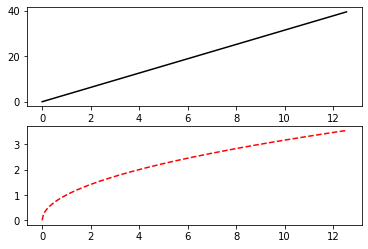

```python
#このコードの一部を書き換えて、上にf(t)=sin(t),下にf(t)=cos(t)のグラフを表示してみてね
import numpy as np
import matplotlib.pyplot as plt
#横軸
t = np.arange(0.0, np.pi*4, 0.05)

plt.figure(1)
ax = plt.subplot(211)
ax.plot(t, np.pi*t, 'k')

ax = plt.subplot(212)
ax.plot(t, np.sqrt(t), 'r--')
plt.show()
```

```python
#一問目のように、一つの描画キャンパスの上に、複数のグラフを表示したい
#横にグラフが二つ並ぶような感じで、左のグラフにはグラフを複数重ねてみてね
#グラフの内容はなんでもおっけー
import numpy as np
import matplotlib.pyplot as plt

#ここに書いてね


plt.show()
```

[figure not shown]

```python
#こんな感じ用
```

```python
#エクストラがんばれ問題③で出た、機械学習の教師データっぽいデータを全部プロットしてね
#うち一つの点に、垂直線を表示してみてね
import random
random.seed(0)
train_x=[[random.randint(0, 100), random.randint(0, 100)] for i in range(10)]
train_y=[0 if i[0]<50 else 1 for i in train_x ]

print(train_x)
print(train_y)
```